# Project: Investigating a Movie Dataset

- Introduction
- Data Wrangling
- Exploratory Data Analysis
- Conclusion
- Limitation

## Introduction

We are going to explore a Movie Dataset to do our analysis.In this dataset set we have various variables such as Movie Genres,Budget for making ,revenue collected to state a few.we will try to get insight of various factors which will answer our stated questions below.from this dataset will try to give insight on following questions:

> 1.How a movie will perform in terms of revenue based upon the popularity?

> 2.What type of genre is popular?

> 3.Does budget really decides the popularity of a given movie or is its just the content of the Movie which matters ?

> 4.Are more number of movies created as years goes by and what is average runtime for most movies ?

### Importing all the necessary LibrarIes

```python
import numpy as np
import pandas as pd
import matplotlib.pyplot as plt
from matplotlib import pyplot
import seaborn as sns
%matplotlib inline
```

# Data Wrangling

Always before analysing any dataset we must first understand the following

> Dataset structure

> Variables that defines particular qualities of the dataset given

> Dimension/Shape of the dataset

> Each variables type.

Following through the above process can give us more understanding about the given dataset which makes our further anaylsis step easier.

#### load the Movie dataset

```python
df=pd.read_csv('tmdb-movies.csv')
```

#### 1.Dataset structure

```python
df.head()
```

|  | id | imdb_id | popularity | budget | revenue | original_title | cast | homepage | director | tagline | ... | overview | runtime | genres | production_companies | release_date | vote_count | vote_average | release_year | budget_adj | revenue_adj |
| --- | --- | --- | --- | --- | --- | --- | --- | --- | --- | --- | --- | --- | --- | --- | --- | --- | --- | --- | --- | --- | --- |
| 0 | 135397 | tt0369610 | 32.985763 | 150000000 | 1513528810 | Jurassic World | Chris Pratt\|Bryce Dallas Howard\|Irrfan Khan\|Vi... | http://www.jurassicworld.com/ | Colin Trevorrow | The park is open. | ... | Twenty-two years after the events of Jurassic ... | 124 | Action\|Adventure\|Science Fiction\|Thriller | Universal Studios\|Amblin Entertainment\|Legenda... | 6/9/15 | 5562 | 6.5 | 2015 | 1.379999e+08 | 1.392446e+09 |
| 1 | 76341 | tt1392190 | 28.419936 | 150000000 | 378436354 | Mad Max: Fury Road | Tom Hardy\|Charlize Theron\|Hugh Keays-Byrne\|Nic... | http://www.madmaxmovie.com/ | George Miller | What a Lovely Day. | ... | An apocalyptic story set in the furthest reach... | 120 | Action\|Adventure\|Science Fiction\|Thriller | Village Roadshow Pictures\|Kennedy Miller Produ... | 5/13/15 | 6185 | 7.1 | 2015 | 1.379999e+08 | 3.481613e+08 |
| 2 | 262500 | tt2908446 | 13.112507 | 110000000 | 295238201 | Insurgent | Shailene Woodley\|Theo James\|Kate Winslet\|Ansel... | http://www.thedivergentseries.movie/#insurgent | Robert Schwentke | One Choice Can Destroy You | ... | Beatrice Prior must confront her inner demons ... | 119 | Adventure\|Science Fiction\|Thriller | Summit Entertainment\|Mandeville Films\|Red Wago... | 3/18/15 | 2480 | 6.3 | 2015 | 1.012000e+08 | 2.716190e+08 |
| 3 | 140607 | tt2488496 | 11.173104 | 200000000 | 2068178225 | Star Wars: The Force Awakens | Harrison Ford\|Mark Hamill\|Carrie Fisher\|Adam D... | http://www.starwars.com/films/star-wars-episod... | J.J. Abrams | Every generation has a story. | ... | Thirty years after defeating the Galactic Empi... | 136 | Action\|Adventure\|Science Fiction\|Fantasy | Lucasfilm\|Truenorth Productions\|Bad Robot | 12/15/15 | 5292 | 7.5 | 2015 | 1.839999e+08 | 1.902723e+09 |
| 4 | 168259 | tt2820852 | 9.335014 | 190000000 | 1506249360 | Furious 7 | Vin Diesel\|Paul Walker\|Jason Statham\|Michelle ... | http://www.furious7.com/ | James Wan | Vengeance Hits Home | ... | Deckard Shaw seeks revenge against Dominic Tor... | 137 | Action\|Crime\|Thriller | Universal Pictures\|Original Film\|Media Rights ... | 4/1/15 | 2947 | 7.3 | 2015 | 1.747999e+08 | 1.385749e+09 |

5 rows × 21 columns

By looking at the structure of movie dataset,we can see there are lot of variables/qualites which are unnecessary or useless for our Analysis and creates more confusion . once we are done with Data wrangling step we can (DROP or Select only those variables needed represented by new dataframe) those column labels in Data cleaning step.

#### 2.Variables that defines particular qualities of the dataset given

From the above structure we can say the variables like popularity,budget,original_title,runtime,genres,release_year,vote_count will be very helpful in our quest to search answer's for the above proposed questions.

#### 3.Dimension/Shape of the dataset

```python
df.shape
```

```
(10866, 21)
```

#### 4.Each variables type.

```python
df.info()
```

```
<class 'pandas.core.frame.DataFrame'>
RangeIndex: 10866 entries, 0 to 10865
Data columns (total 21 columns):
id                      10866 non-null int64
imdb_id                 10856 non-null object
popularity              10866 non-null float64
budget                  10866 non-null int64
revenue                 10866 non-null int64
original_title          10866 non-null object
cast                    10790 non-null object
homepage                2936 non-null object
director                10822 non-null object
tagline                 8042 non-null object
keywords                9373 non-null object
overview                10862 non-null object
runtime                 10866 non-null int64
genres                  10843 non-null object
production_companies    9836 non-null object
release_date            10866 non-null object
vote_count              10866 non-null int64
vote_average            10866 non-null float64
release_year            10866 non-null int64
budget_adj              10866 non-null float64
revenue_adj             10866 non-null float64
dtypes: float64(4), int64(6), object(11)
memory usage: 1.7+ MB
```

Datatypes of each essential qualities are all in preffered format so need to change the datatype

## Cleaning the data

In order to further analyse the movie dataset we must clean and refine the dataset that is detecting and correcting corrupt or inaccurate records from a record set, table, or database and refers to identifying incomplete, incorrect, inaccurate or irrelevant parts of the data and then replacing, modifying, or deleting the dirty or coarse data

#### step1.Create a dataframe with only relevant variables to do our analysis

Here as discussed earlier we are selecting particular variables/Labels and representing those with a new dtaframe named df_movies, moving forward we will refer the new data frame created instead of df for our Analysis.

```python
col_labels=['id','popularity','budget','revenue','original_title','runtime','genres','release_year','vote_count']
df1=df[col_labels]
df1.head()
```

|  | id | popularity | budget | revenue | original_title | runtime | genres | release_year | vote_count |
| --- | --- | --- | --- | --- | --- | --- | --- | --- | --- |
| 0 | 135397 | 32.985763 | 150000000 | 1513528810 | Jurassic World | 124 | Action\|Adventure\|Science Fiction\|Thriller | 2015 | 5562 |
| 1 | 76341 | 28.419936 | 150000000 | 378436354 | Mad Max: Fury Road | 120 | Action\|Adventure\|Science Fiction\|Thriller | 2015 | 6185 |
| 2 | 262500 | 13.112507 | 110000000 | 295238201 | Insurgent | 119 | Adventure\|Science Fiction\|Thriller | 2015 | 2480 |
| 3 | 140607 | 11.173104 | 200000000 | 2068178225 | Star Wars: The Force Awakens | 136 | Action\|Adventure\|Science Fiction\|Fantasy | 2015 | 5292 |
| 4 | 168259 | 9.335014 | 190000000 | 1506249360 | Furious 7 | 137 | Action\|Crime\|Thriller | 2015 | 2947 |

#### step2:check for Non null/missing values and remove if any

Now since we have a relevant dataframe we can check for missing values and this can be performed by following code where it return boolean 'True' if there is missing value in given column and 'False' if there is no

#### 1.Removing Nan values

```python
df1.isnull().any(axis=0)  #axis=0 for columns and 1 for rows
```

```
id                False
popularity        False
budget            False
revenue           False
original_title    False
runtime           False
genres             True
release_year      False
vote_count        False
dtype: bool
```

```python
#we will remove the entries with Nan values

df1.dropna(inplace=True)

df1.info()
```

```
<class 'pandas.core.frame.DataFrame'>
Int64Index: 10843 entries, 0 to 10865
Data columns (total 9 columns):
id                10843 non-null int64
popularity        10843 non-null float64
budget            10843 non-null int64
revenue           10843 non-null int64
original_title    10843 non-null object
runtime           10843 non-null int64
genres            10843 non-null object
release_year      10843 non-null int64
vote_count        10843 non-null int64
dtypes: float64(1), int64(6), object(2)
memory usage: 847.1+ KB
```

#### step2:Remove duplicates

we need to remove redundant rows from the dataframe to do that firstly we need to check wether we have any duplicates or not

```python
#check for duplicates ie check for duplicates count
sum(df1.duplicated())
```

```
1
```

```python
#removing duplicates
df1.drop_duplicates(inplace=True)
df1.info()
```

[output not shown]

In this way we performed Data wrangling and Data cleaning in order to get a relevant dataset now we can apply codes in order to answers to the above proposed questions along with visuals in order to get more insights into the dataset.

### 3.Split each Genre into separate rows

As per our observation ,there are multiple values in a generes which needs to be seperated using split and the seperator seperating those values ie(|) and create a new column named genre and will remove the older genres.

```python
df_genre=df1.join(df1.genres.str.strip('|').str.split('|',expand=True).stack().reset_index(level=1,drop=True).rename('genre')).reset_index(drop=True)
```

```python
#drop the older genres colums since its irrelevant
df1=df_genre.drop(['genres'],axis=1)
df1.head()
```

|  | id | popularity | budget | revenue | original_title | runtime | release_year | vote_count | genre |
| --- | --- | --- | --- | --- | --- | --- | --- | --- | --- |
| 0 | 135397 | 32.985763 | 150000000 | 1513528810 | Jurassic World | 124 | 2015 | 5562 | Action |
| 1 | 135397 | 32.985763 | 150000000 | 1513528810 | Jurassic World | 124 | 2015 | 5562 | Adventure |
| 2 | 135397 | 32.985763 | 150000000 | 1513528810 | Jurassic World | 124 | 2015 | 5562 | Science Fiction |
| 3 | 135397 | 32.985763 | 150000000 | 1513528810 | Jurassic World | 124 | 2015 | 5562 | Thriller |
| 4 | 76341 | 28.419936 | 150000000 | 378436354 | Mad Max: Fury Road | 120 | 2015 | 6185 | Action |

## Exploratory Data Analysis with conclusions

### 1.How a movie will perform in terms of revenue based upon the popularity?

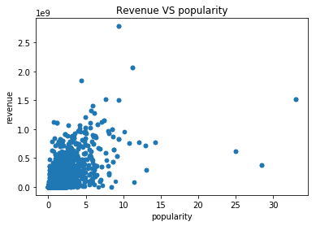

```python
df1.plot(x='popularity',y='revenue',kind='scatter');

plt.title("Revenue VS popularity");
```

#### observation :

From the above scattered plot we can say,

> Most movies with less popularity tends to generate less revenue in Boxoffice,

> As the movie garner good popularity, it tends to generate more in revenue,

> There are Exceptional cases in which Movies with good popularity collected less revenue and Movies with average popularity tends to generate more revenue.

#### 2.What type of genre is popular?

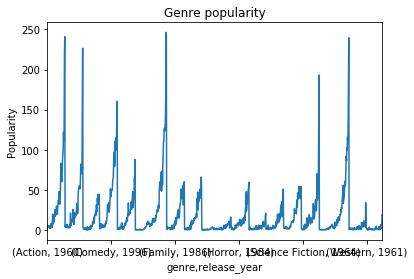

```python
#group genre with release year and find popularity for each year along with genre
df2=df1.groupby(['genre','release_year']).sum()['popularity']
df2.plot();
plt.ylabel("Popularity");
plt.title("Genre popularity");
```

#### observation :

From the above plot we can say,

#### 3.Does budget really decides the popularity of a given movie or is its just the content of the Movie which matters ?

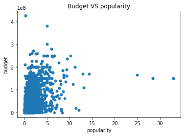

```python
df1.plot(x="popularity",y="budget",kind="scatter");
plt.title("Budget VS popularity");
```

#### observation :

From the above scattered plot we can say that,

Its evident that movies with higher budgets sometimes doesnt gain that much of popularity as many of the times contents do matter only few movies are popular having higher budget.

#### 4. Are more number of movies created as years goes by and what is average runtime for most movies ?

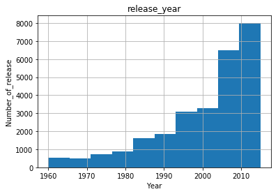

```python
df1.hist("release_year");
plt.xlabel("Year");
plt.ylabel("Number_of_release");
```

#### observation :

As from the given above histogram its clear that as the years pass by more and more movies are released per year

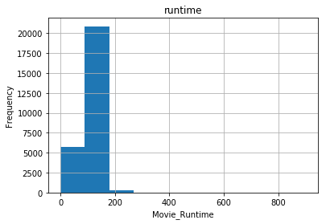

```python
df1.hist("runtime");
plt.xlabel("Movie_Runtime");
plt.ylabel("Frequency");
```

#### observation :

As from the given above histogram we can that say that most of the movies has the runtime in the range of 100 - 175 minutes.

## Conclusion

We had about 10000 data samples,which is good number of samples in order to carry any analysis on a dataset Higher the data samples,more you can trust on the outcomes of predictions and the visulaization showcased above. We have done a lot of data cleaning ,so that we can get good predictions and tried to answer the possible outcome upon the questions we have asked and have made an best possible way to answer those with diffirent plot visulaizations.

## Limitation

There are few limiations as well in our analysis they are as follows,

1.we had many missing values present in the given dataset hence this made our prediction and plot very limited in views of insights.

2.Also we tried to answer the 2nd question , Here we outrightly said some genre were popular but in fact there was just a one tag,As in the raw data we saw many/most of the movies are made having many genre which makes a movie complete.

But based upon only statistic extracted we managed to point out only few genre were popular among the audience which is not completely true.

## Submitting your Project

> Before you submit your project, you need to create a .html or .pdf version of this notebook in the workspace here. To do that, run the code cell below. If it worked correctly, you should get a return code of 0, and you should see the generated .html file in the workspace directory (click on the orange Jupyter icon in the upper left).

> Alternatively, you can download this report as .html via the **File** > **Download as** submenu, and then manually upload it into the workspace directory by clicking on the orange Jupyter icon in the upper left, then using the Upload button.

> Once you've done this, you can submit your project by clicking on the "Submit Project" button in the lower right here. This will create and submit a zip file with this .ipynb doc and the .html or .pdf version you created. Congratulations!

```python
from subprocess import call
call(['python', '-m', 'nbconvert', 'Investigate_a_Dataset1.ipynb'])
```

```
255
```